# Time series in the analysis of truck sales

## Data

|  | 1 | 2 | 3 | 4 | 5 | 6 |
| --- | --- | --- | --- | --- | --- | --- |
| YearMonth | 03-Jan | 03-Feb | 03-Mar | 03-Apr | 03-May | 03-Jun |
| Sales | 155 | 173 | 204 | 219 | 223 | 208 |

The following dataset shows monthly truck sales data from 2003 to 2014. It includes information on the number of trucks sold in each month.

## Basic statistics

|  | N obs. | Średnia | Odch. stand. | Min | 1 kwartyl | Mediana | 3 kwartyl | Max |
| --- | --- | --- | --- | --- | --- | --- | --- | --- |
| Value | 144.0000 | 428.7292 | 188.6330 | 152.0000 | 273.5000 | 406.0000 | 560.2500 | 958.0000 |

## Data visualization

### Basic charts

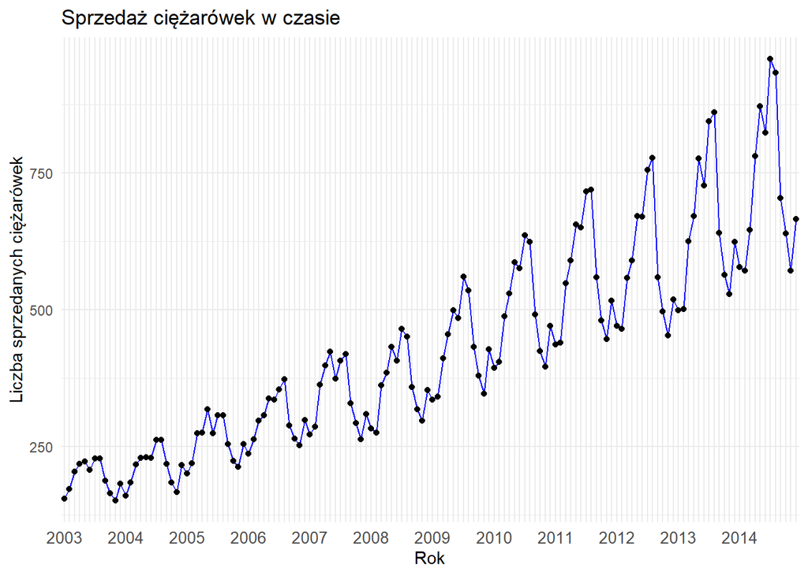

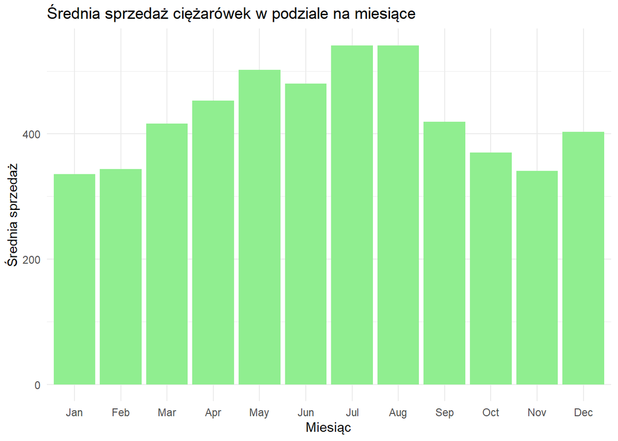

**Seasonality of sales:** The highest average sales occur during the summer (May-August), suggesting that summer is the most active time in the industry. **Best months:** July and August lead the way in terms of average sales, which may be due to companies preparing before the end of the third quarter.**Lower sales:** The lowest results occur in January and February, which can be linked to the New Year period and lower investment activity.**Slow growth:** From March to May, sales rise steadily, peaking in the summer and then falling in September and October, indicating a seasonal slowdown after the vacations.

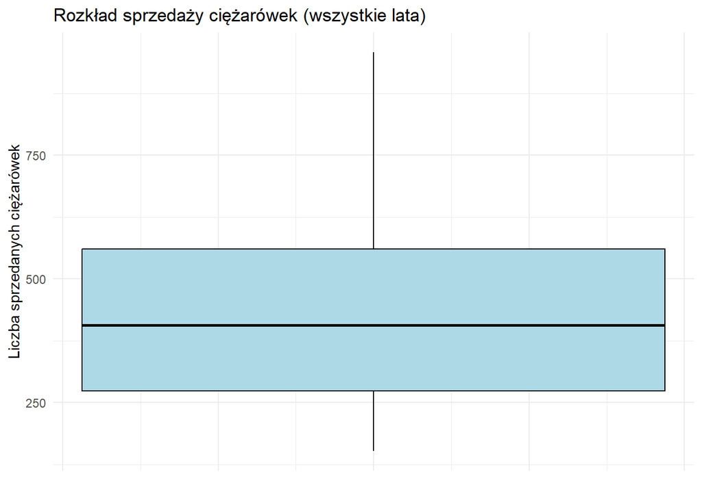

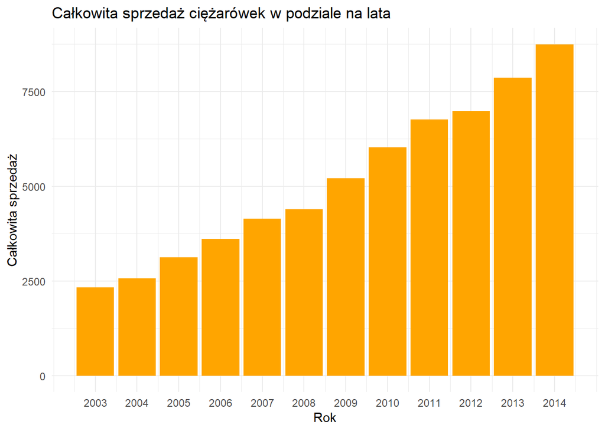

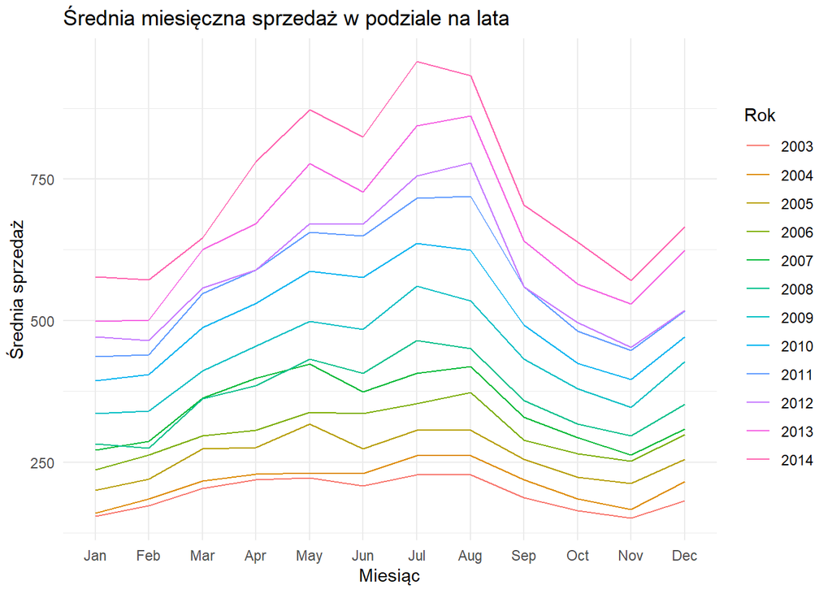

### Time series analysis

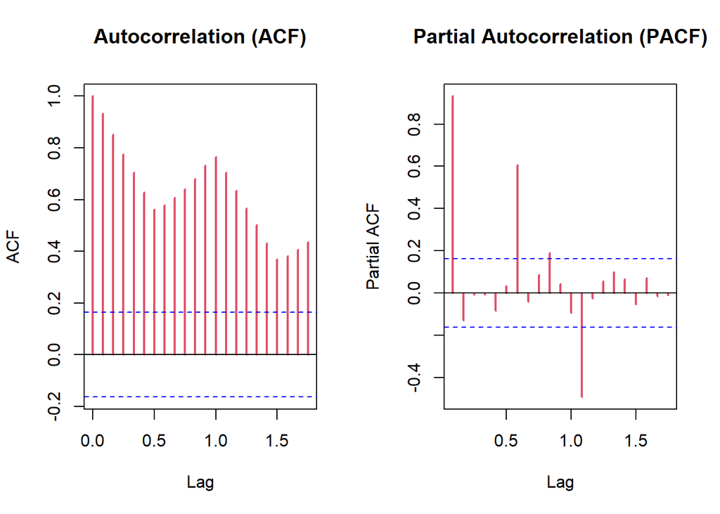

The graph shows ACF and PACF. ACF declines slowly, indicating a minor role for the MA component, while the sharp decline in PACF suggests a greater influence of the AR component.

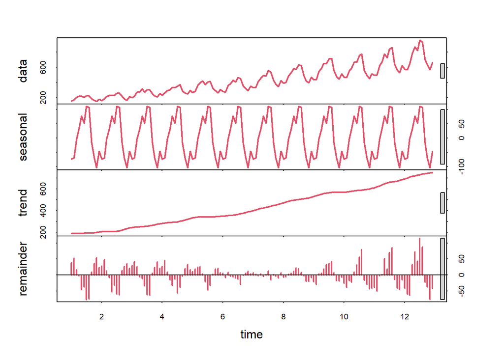

The graph shows the decomposition of the time series using the STL method. The seasonal component confirms the presence of regular patterns, the trend indicates long-term growth, and the residual component contains random fluctuations. The data can be described taking into account both trend and seasonality.

### Stationarity of the time series

In the previous graph, you can see that the time series has an upward trend and seasonality, which means that it is not stationary. So, we need to do differentiation to make it stationary. So we will do a first-order differentiation we will do a visualization and check it with appropriate tests.

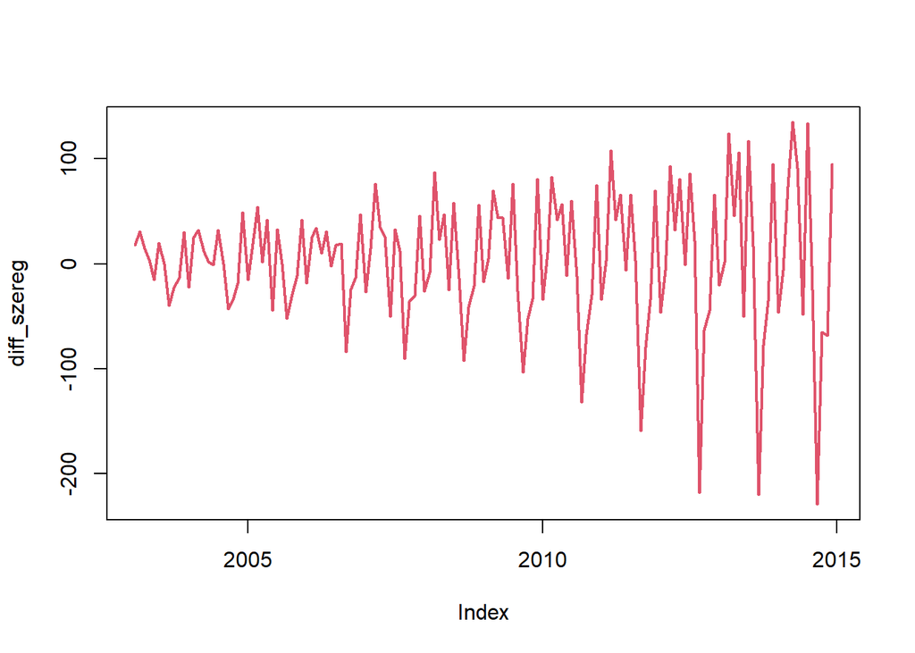

In the given graph you can see that the first-order variation made the time series stationary. Now we will check it with the appropriate tests.

|  | Nazwa_testu | Statystyka | p_value |
| --- | --- | --- | --- |
| Dickey-Fuller | Augmented Dickey-Fuller | -15.1206382 | 0.01 |
| KPSS Level | Kwiatkowski-Phillips-Schmidt-Shin | 0.0124762 | 0.10 |
| Dickey-Fuller Z(alpha) | Phillips-Perron | -110.1168101 | 0.01 |

Three tests supported the stationarity of the time series.

## Holt-Winters

```r
model_holtwinters <- HoltWinters(train_ts,seasonal="multiplicative")
```

The parameter `seasonal=“multiplicative”` takes into account seasonality, the amplitude of which changes in proportion to the level of the trend, which fits data with an increasing trend and intensifying seasonality.

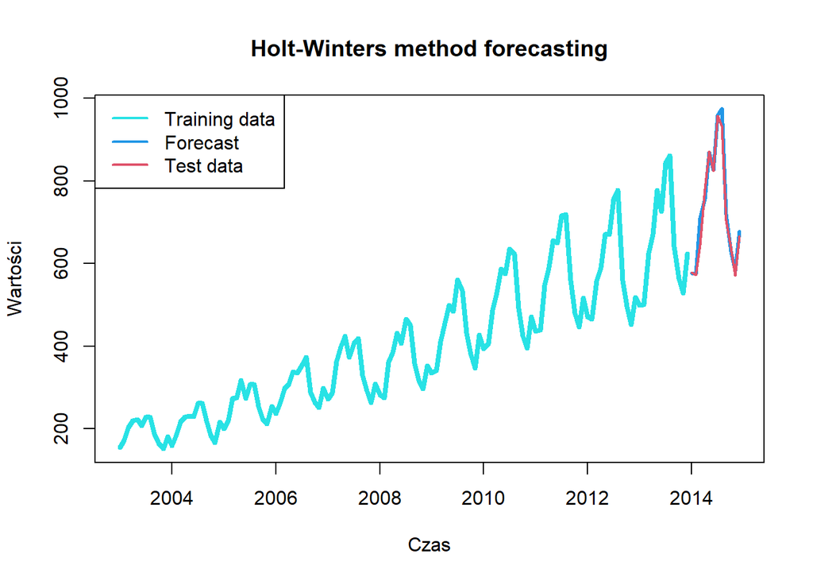

The forecast shows seasonality and trend in the training data well, which means that the method has correctly captured patterns in the data. Comparing the forecast with the test data shows that the model works well, although there may be minor differences.

### Checking the assumptions

|  | Nazwa_testu | Statystyka | p_value |
| --- | --- | --- | --- |
| W | Shapiro-Wilk | 0.9791780 | 0.0597338 |
| A | Anderson-Darling | 0.7282517 | 0.0561049 |
| BP | Breusch-Pagan | 10.7081965 | 0.0300468 |
| GQ | Goldfeld-Quandt | 1.3427149 | 0.1387731 |

In the tests performed, we can see that the assumption of normality of errors has been met, because in both tests the p-values are greater than 0.05. The assumption of homogeneity of variance has been violated, because in the first test the p-value is less than 0.05, which forces us to reject the null hypothesis, although and Goldfeld-Quandt test says to accept it.

## Polynomial regression

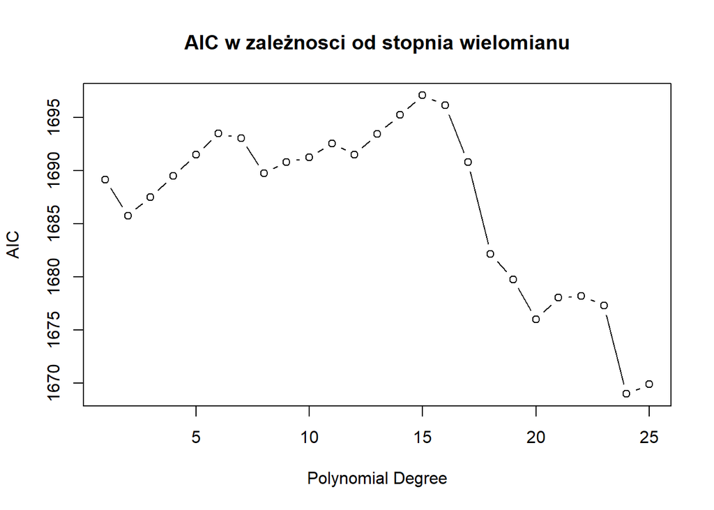

The graph shows that the best degree of the polynomial is 24, since it has the lowest AIC score.

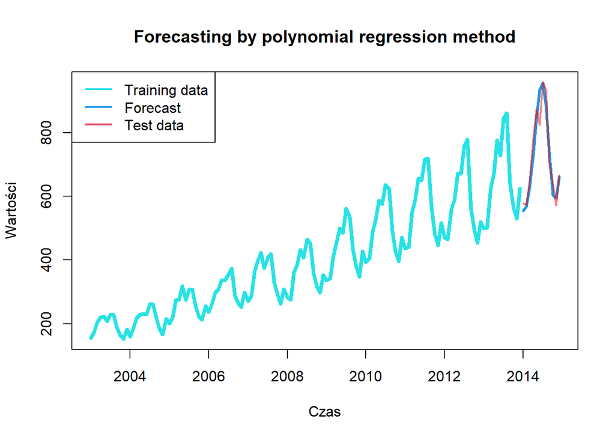

### Diagnostic charts

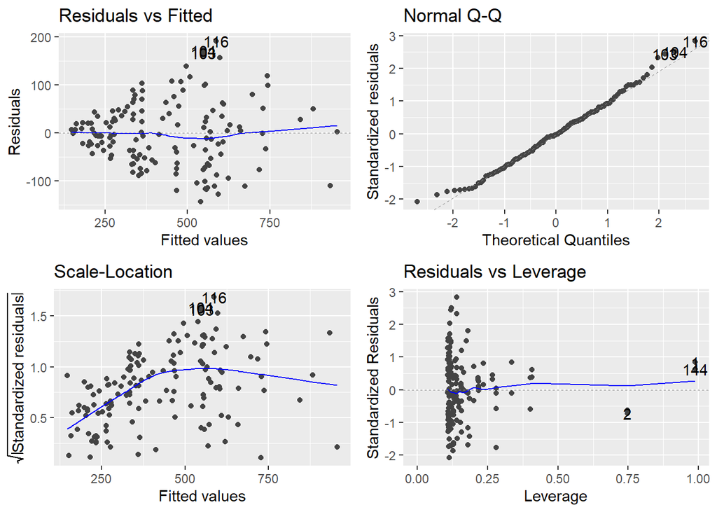

The diagnostic charts indicate that the polynomial regression model may have some problems. The “Residuals vs Fitted” graph shows curvature, suggesting that the model has not fully captured the structure of the data. The “Normal Q-Q” graph shows that the residuals are not perfectly normally distributed, especially at the ends, indicating a possible deviation from the assumption of normality. “Scale-Location” shows an increasing variance of the residuals, which may suggest a heteroskedasticity problem. The “Residuals vs Leverage” chart identifies several points of high influence (high leverage) that may significantly affect the model fit.

### Checking the assumptions

|  | Nazwa_testu | Statystyka | p_value |
| --- | --- | --- | --- |
| W | Shapiro-Wilk | 0.9887849 | 0.3004680 |
| A | Anderson-Darling | 0.2782367 | 0.6454426 |
| BP | Breusch-Pagan | 18.4647172 | 0.0000173 |
| GQ | Goldfeld-Quandt | 3.5644317 | 0.0000001 |
| DW | Durbin-Watson | 0.7288279 | 0.0000000 |
| LM test | Breusch-Godfrey | 58.3443941 | 0.0000000 |

## SARIMA

```r
sarima <- auto.arima(train_ts, seasonal = TRUE, stepwise = FALSE, approximation = FALSE)
summary(sarima)
```

```
## Series: train_ts
## ARIMA(1,1,0)(2,1,0)[12]
##
## Coefficients:
##           ar1     sar1    sar2
##       -0.2851  -0.0826  0.2318
## s.e.   0.0918   0.0919  0.1049
##
## sigma^2 = 287.9:  log likelihood = -505.03
## AIC=1018.05   AICc=1018.4   BIC=1029.17
##
## Training set error measures:
##                     ME     RMSE      MAE      MPE    MAPE      MASE        ACF1
## Training set 0.8079424 15.90494 11.86291 0.045109 2.96353 0.2546599 0.007296978
```

This code snippet uses the `auto.arima` function from the `forecast` package to automatically construct the `SARIMA` model. The SARIMA model includes both autoregressive $AR$ and seasonal $SAR$ components adjusted for data with pronounced trend and seasonality. The coefficients of the model indicate a moderate effect of ordinary and seasonal lags on the time series. The model has a good fit, as evidenced by low error values and low autocorrelation of residuals($ACF1 = 0.0073$). The `SARIMA` model, based on the estimated parameters, can be written in the form:
$$(1
+ 0.2851 B)(1 + 0.0826 B^{12} - 0.2318 B^{24})(1 - B)(1 - B^{12}) Y_t =
\epsilon_t$$
.

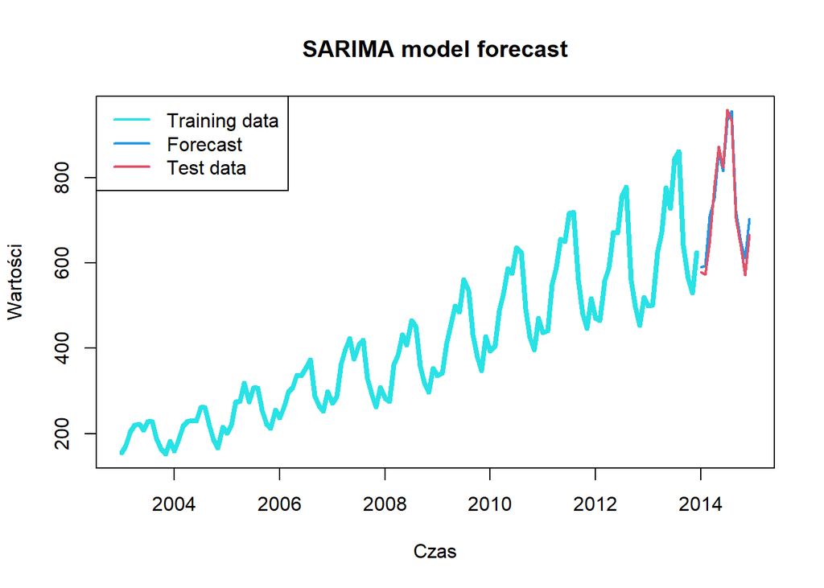

The graph shows a time series forecast made using the SARIMA model. The forecast reproduces the test data well, taking into account both trend and seasonality, which shows the effectiveness of the model in analyzing this type of data.

### Checking the assumptions

|  | Nazwa_testu | Statystyka | p_value |
| --- | --- | --- | --- |
| W | Shapiro-Wilk | 0.9826246 | 0.0902160 |
| A | Anderson-Darling | 0.8190532 | 0.0334795 |
| BP | Breusch-Pagan | 9.4122285 | 0.0021554 |
| GQ | Goldfeld-Quandt | 1.5518511 | 0.0405796 |

The assumption of normality of the residuals was violated because the p-value is less than 0.05 in the second test. The assumption of homogeneity of variance was also violated because the p-values are less than 0.05 in both tests.

## Model comparison

| Model | R2 | MAE | MSE | RMSE | MAPE |
| --- | --- | --- | --- | --- | --- |
| Holt-Winters | 0.9913795 | 15.63479 | 585.4071 | 24.19519 | 2.196681 |
| Polynomial Regression | 0.8752309 | 31.94093 | 1817.4034 | 42.63102 | 4.264551 |
| SARIMA | 0.9909566 | 25.11870 | 859.8484 | 29.32317 | 3.655697 |

Based on a comparison of the results of the three models (Holt-Winters, Polynomial Regression, SARIMA), it can be seen that the Holt-Winters model performed best in all key measures. The SARIMA model performed slightly worse, with higher errors and smaller $R^2$, but still outperformed Polynomial Regression. Polynomial regression was the least effective, with the highest error values, which may be due to the difficulty in capturing complex seasonal patterns in the data.

### Visualization of results

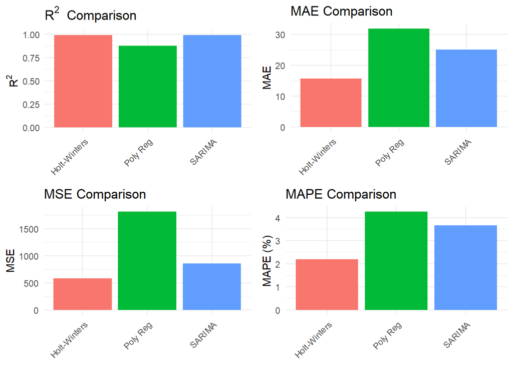

## Conclusions:

**Holt-Winters:**  
The Holt-Winters model is the best model for forecasting truck sales because it has achieved the best results in key metrics. It is able to reproduce both trend and seasonality in the data well, allowing it to accurately forecast future values.  
**Polynomial regression:**  
Polynomial regression was the least effective model because it had the highest error values and lowest $R^2$. It may have difficulty capturing complex seasonal patterns in the data.

**SARIMA:**  
The SARIMA model produced results with slightly higher errors than Holt-Winters, but better than polynomial regression.

So Holt-Winters and SARIMA are good models for time series analysis, and depending on the data, they may show better or worse results when comparing one with the other, but both give quite good results and are very effective in time series analysis.